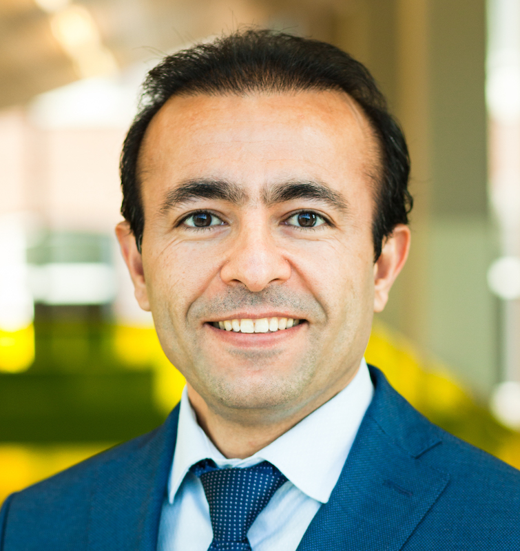

# Reza Mohammadi

## Bio

I am an Assistant Professor of Data Science at the Business Analytics Section of the University of Amsterdam. As a data scientist and statistician, my research interests lie in developing efficient computational methods for inference and learning from high-dimensional multivariate data that routinely arise in econometrics, machine learning, neuroscience, and health care. My current research is focused on developing Bayesian statistical methods in graphical models for multivariate statistical analysis to understand the underlying mechanisms in complex systems. These methods have a wide range of applications, such as health care to capture brain connectivity to treat Alzheimer’s.

## Experience

**University of Amsterdam** | Assistant Professor (tenure-track) | December 2017 - Present

**York University** | Guest Researcher | February 2018 - May 2018

**Tilburg University** | Postdoctoral Fellow | January 2016 - November 2017

**University of Groningen** | Ph.D. Researcher | April 2011 - April 2015